# Naa10 het heart

Naa10 heterozygous mutant (+/- or +/-) heart lysate analysis

Fresh or thawed flash-frozen tissue were lysed in RIPA buffer supplemented with protease inhibitor tablets (Sigma-Aldrich, #R0278; Roche #11836153001). Tissue was homogenized using a handheld motorized microtube pestle. Lysate was then cleared after centrifugation (15,000 rcf, 20 minutes). Total protein was quantified using Advanced Protein Assay Reagent (Cytoskeleton Inc., #ADV02). Lysate was then diluted in 2X SDS-PAGE Sample Buffer (5% v/v 2-mercaptoethanol) and heated (95 - 100ºC, 5 minutes).

20 µg of protein were resolved on a a 10% mini-PROTEAN TGX gel (Bio-Rad, #4561033). SDS-PAGE gel was equilibrated in chilled Towbin’s transfer buffer. Proteins were transferred from gel to 0.2 µm nitrocellulose membrane (Amersham) at 100V, 30 minutes under refrigeration. After transfer, membrane was allowed to dry at least 1 hour. Membranes were stained for transfer verification and total protein sing REVERT 700 total protein stain (Li-cor, #926-11015).

After stain removal, membrane was blocked in TBS with 5% non-fat dry milk (1 hr, RT). After decanting blocking buffer, membrane was incubated (overnight, 4ºC) in 1/500 anti-NAA10 (diluted in blocking buffer supplemented with 0.1% v/v Tween-20). Membrane was then washed 5 minutes in TBS-T for 3 repetitions. Membrane was then incubated (1 hr, RT) using 1/20000 goat-anti-rabbit IR800 CW (Li-cor, 926-32211). Membrane was again washed 5 minutes in TBS-T for 3 repetitions and then briefly rinsed in TBS. Membrane was allowed to dry before imaging.

Immunostained membranes were imaged on Odyssey Classic (Li-cor). Analysis was conducted and plotted using Empiria Studio (Li-cor) and R.

#Source data ##individual dataset

```r
library(tidyverse)
heart <- read.csv("https://docs.google.com/spreadsheets/d/e/2PACX-1vQB2mYpWBkzsQdS7n3FiqKXF70ePN7vz6znR5W75U2IFpwV953plycKWctxmu3q0A/pub?gid=1982809102&single=true&output=csv", header = T)
```

```r
head(heart)
```

```
##   ID Name         Genotype Replicate       MW    Signal  Total Background Area
## 1  6 5218        Naa10 +/+         A 33.27017  86576.59 650583   640.9164  880
## 2  6 5218        Naa10 +/+         C 32.96922 195341.31 767017   610.7646  936
## 3  6 5218        Naa10 +/+         B 35.32206  37625.34 657986   904.3159  686
## 4  5 5217 Naa10 +/- or -/+         A 31.46597  44084.17 876624   639.4315 1302
## 5  5 5217 Naa10 +/- or -/+         C 32.71951  62252.37 556679   607.4037  814
## 6  5 5217 Naa10 +/- or -/+         B 35.32206  15022.95 370516   906.8701  392
##   Normalized.Signal fold.change Amount..µg.       SNR Avg..Norm..Signal
## 1         209615.47   1.0000000          20  9.485736         219605.30
## 2         198543.05   1.0000000          20 19.498918         224304.30
## 3          67522.91          NA          20  3.074115          47391.42
## 4          76604.80   1.1345009          20  3.007319          68940.00
## 5          62252.37   0.8126432          20  7.570556          79359.12
## 6          22516.27          NA          20  2.020845          15260.69
##    Avg..SNR Std..Dev.     X..CV   Type
## 1 11.458186 11883.485  5.411293 Sample
## 2 14.565121 23387.105 10.426507 Sample
## 3  2.603499 19397.694 40.930818 Sample
## 4  5.590801 13210.829 19.162791 Sample
## 5  7.244696 24398.774 30.744764 Sample
## 6  1.471250  6939.802 45.475021 Sample
```

```r
##double-check genotypes of biological replicates
```

```r
##switched Name and Replicate fromn integers to factors
heart$ID <- as.factor(heart$ID)
heart$Name <- as.factor(heart$Name)
heart$Replicate <- as.factor (heart$Replicate)
heart$Genotype <- as.factor(heart$Genotype)

head(heart)
```

```
##   ID Name         Genotype Replicate       MW    Signal  Total Background Area
## 1  6 5218        Naa10 +/+         A 33.27017  86576.59 650583   640.9164  880
## 2  6 5218        Naa10 +/+         C 32.96922 195341.31 767017   610.7646  936
## 3  6 5218        Naa10 +/+         B 35.32206  37625.34 657986   904.3159  686
## 4  5 5217 Naa10 +/- or -/+         A 31.46597  44084.17 876624   639.4315 1302
## 5  5 5217 Naa10 +/- or -/+         C 32.71951  62252.37 556679   607.4037  814
## 6  5 5217 Naa10 +/- or -/+         B 35.32206  15022.95 370516   906.8701  392
##   Normalized.Signal fold.change Amount..µg.       SNR Avg..Norm..Signal
## 1         209615.47   1.0000000          20  9.485736         219605.30
## 2         198543.05   1.0000000          20 19.498918         224304.30
## 3          67522.91          NA          20  3.074115          47391.42
## 4          76604.80   1.1345009          20  3.007319          68940.00
## 5          62252.37   0.8126432          20  7.570556          79359.12
## 6          22516.27          NA          20  2.020845          15260.69
##    Avg..SNR Std..Dev.     X..CV   Type
## 1 11.458186 11883.485  5.411293 Sample
## 2 14.565121 23387.105 10.426507 Sample
## 3  2.603499 19397.694 40.930818 Sample
## 4  5.590801 13210.829 19.162791 Sample
## 5  7.244696 24398.774 30.744764 Sample
## 6  1.471250  6939.802 45.475021 Sample
```

```r
##changed Name and Replicate from integer data to replicate data
```

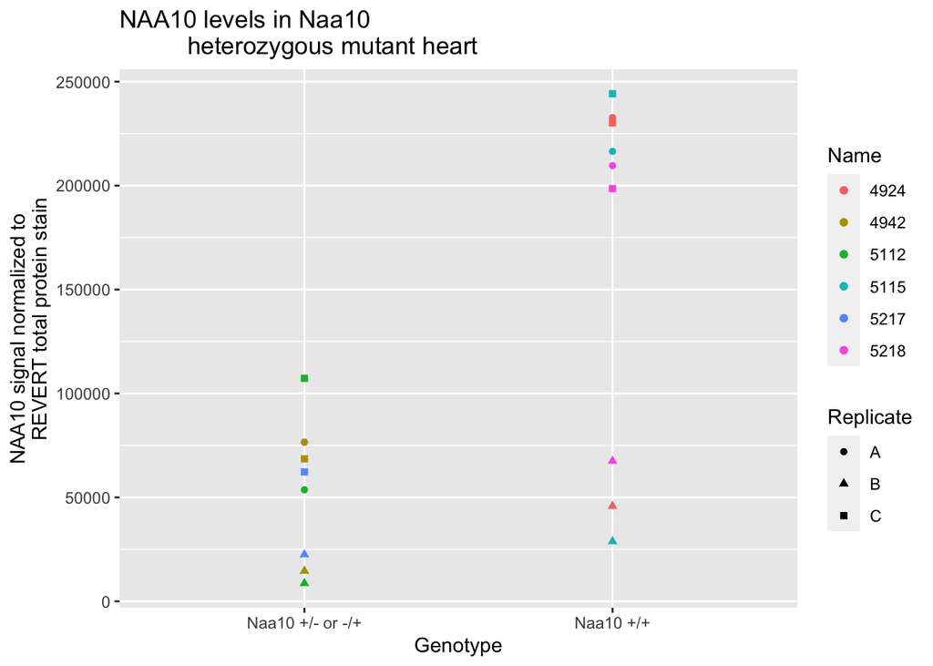

```r
ggplot(heart,aes(x = Genotype,
                 y = Normalized.Signal,
                 color = Name,
                 shape = Replicate))+
  geom_point()+
  ylab("NAA10 signal normalized to
       REVERT total protein stain")+
  ggtitle("NAA10 levels in Naa10
          heterozygous mutant heart")
```